# The US population

Regression is a staple of predictive analytics. Linear regression is a process where we fit the best line where we base our prediction of the data, then we find the R^2 which tells us how close these predictions where to the actual results, and finaly we find the P-value to deternine if there is significant evidence that these two datasets are coorelated. Perfect for predicting the out come out of a continous dataset. I have chosen the US population as a topic where I can explore the predictive techniques used in linear regressional models. In Kraggle I found a currennt dataset of US population form 1790-2024. I chose this dataset for its simplicity, as it only has the required column to make this for this project. I'm going to use linear regression to predict the population of the states, and the entire country. I hope that with this practices, not only would I apply regression, but to also make informative prediction of future US population trends. These trends are vital for city planning, policy making, and state funding. With this project, I hope that I can provide accurate information to these officials, and ensure smart future planning.

```python
#!pip install pandas
#!pip install pycountry
#!pip install scikit-learn
import numpy as np
import matplotlib.pyplot as plt
import matplotlib.colors as mcolors
import pandas as bk
from sklearn.model_selection import train_test_split
from sklearn.metrics import mean_squared_error, r2_score
from sklearn.pipeline import make_pipeline
from sklearn.linear_model import ElasticNet
from sklearn.preprocessing import StandardScaler
from sklearn.preprocessing import PolynomialFeatures
from sklearn.linear_model import LinearRegression
```

This is the dataset, as you can see there wasn't much need to clean the dataset as it was barebones. One thing that I had to consider, since this dataset goes back to all the way to 1790 some states weren't even in the union then. I figured that accounting for this inconsistency would be a waste of time, since the last state joined in 1959 and that is enough time for the dataset to be relevant to modern demographics. Instead of applying weights or figuiring out a way to account for these inconsistencies, I decided to just prune everything before we had 50 states.

```python
df = bk.read_csv("US-population-by-state.csv")
df
```

|  | state | year | population |
| --- | --- | --- | --- |
| 0 | Wisconsin | 1860 | 775881 |
| 1 | West Virginia | 1860 | 376688 |
| 2 | Washington | 1860 | 11594 |
| 3 | Virginia | 1860 | 1219630 |
| 4 | Vermont | 1860 | 315098 |
| ... | ... | ... | ... |
| 6574 | Colorado | 1900 | 543000 |
| 6575 | California | 1900 | 1490000 |
| 6576 | Arkansas | 1900 | 1314000 |
| 6577 | Arizona | 1900 | 124000 |
| 6578 | Alabama | 1900 | 1830000 |

6579 rows × 3 columns

```
    year  population
0   1959   176912000
1   1960   179743000
2   1961   182738000
3   1962   185493000
4   1963   188178000
..   ...         ...
61  2020   330844703
62  2021   331365340
63  2022   333282879
64  2023   336069721
65  2024   339370855

[66 rows x 2 columns]
```

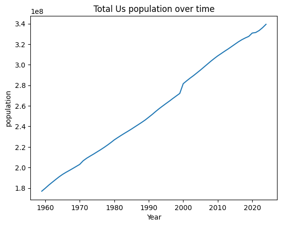

```python
df["year"] = df["year"].astype(int)
df["population"] = df["population"].astype(int)
updated = df[df["year"] >= 1959]
us_pop = updated.groupby("year")["population"].sum().reset_index()
print(us_pop)
plt.plot(us_pop["year"], us_pop["population"])
plt.title("Total Us population over time")
plt.xlabel("Year")
plt.ylabel("population")
plt.show()
```

[output not shown]

[output cut: 112 more lines]

[output not shown]

[figure not shown]

```python
Y = updated["population"]
dummy_col = bk.get_dummies(updated["state"])
X = bk.concat([dummy_col, updated["year"]], axis=1)
X_train, X_test, y_train, y_test = train_test_split(X, Y, test_size = 0.2, random_state = 42)

model = LinearRegression()
model.fit(X_train, y_train)
y_pred = model.predict(X_test)
print(y_pred)
mse = mean_squared_error(y_test, y_pred)
rmse = np.sqrt(mse)
print("Mean Squared Error:", mse)
print("Root Mean Squared Error:", rmse)
lin = bk.Series(model.coef_, index=X_train.columns)

future_years = bk.DataFrame({'year': range(2024, 2035)})
state_columns = bk.get_dummies(updated["state"]).columns
future_predictions = []
for state in state_columns:
    future_state = bk.DataFrame(0, index=future_years.index, columns=state_columns)
    future_state[state] = 1
    X_future = bk.concat([future_state, future_years["year"]], axis=1)
    X_future = X_future[X_train.columns]
    y_future_pred = model.predict(X_future)
    future_predictions.append(y_future_pred)
total_us_pred = np.sum(future_predictions, axis=0)
actual_total = updated.groupby("year")["population"].sum().reset_index()
pred_lin = bk.DataFrame({
    "year": future_years["year"],
    "predicted_population": total_us_pred
})

plt.figure(figsize=(10,6))
plt.plot(actual_total["year"], actual_total["population"], label="Actual (US Total)", marker='o')
plt.plot(pred_lin["year"], pred_lin["predicted_population"], label="Predicted (US Total)", linestyle='--', marker='x')
plt.title("Population Prediction for the US")
plt.xlabel("Year")
plt.ylabel("Population")
plt.legend()
plt.grid(True)
plt.show()
```

Polynomail regression is a regession model that is similar to linear regression, but it is better tailrored for non-linear functions like a population. It does so by fitting the data into a non-linear function where the degree of the polynomial denoted by the user. For the size of this data set I chose to go with a degree of 3, because that is the maximum that my computer can handle (lol). Comapred to typical linear regression, the line should be curved. So I fitted my trained data into the model, and Evaluated by getting its root mean squared error. The rmse is was about 209,569, much lower than linear regression. This mean that this model is off about 209,569 out of 339 million people, thus having a error rate of 0.0617%. This model is about x10 more accurate than the previous model. Plotting the model, you can even see a slight disjoint compared to the linear model. This model is better than the previous one, but I want to see if there is another model that might predict better

```
Mean Squared Error:  43919222421.085815
rsme Score:  209569.13518236842
```

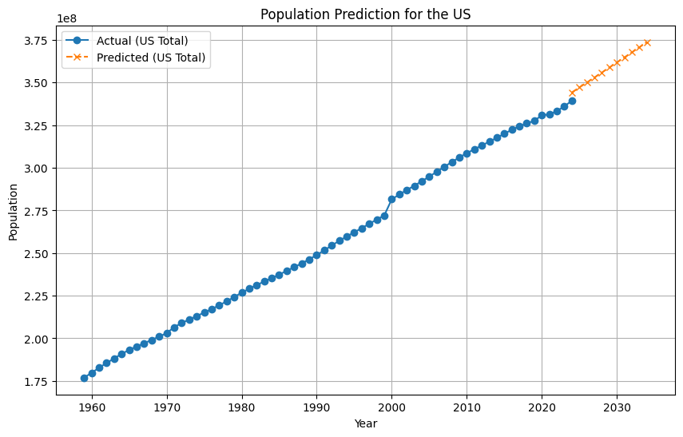

```python
model = make_pipeline(PolynomialFeatures(3), LinearRegression())
model.fit(X_train, y_train)
y_pred = model.predict(X_test)
mse = mean_squared_error(y_test, y_pred)
rmse = np.sqrt(mse)
print(f"Mean Squared Error: ",mse)
print(f"rsme Score: ", rmse)
future_years = bk.DataFrame({'year': range(2024, 2035)})
state_columns = bk.get_dummies(updated["state"]).columns
future_predictions = []
for state in state_columns:
    future_state = bk.DataFrame(0, index=future_years.index, columns=state_columns)
    future_state[state] = 1
    X_future = bk.concat([future_state, future_years["year"]], axis=1)
    X_future = X_future[X_train.columns]
    y_future_pred = model.predict(X_future)
    future_predictions.append(y_future_pred)
total_us_pred = np.sum(future_predictions, axis=0)
actual_total = updated.groupby("year")["population"].sum().reset_index()
pred_pol = bk.DataFrame({
    "year": future_years["year"],
    "predicted_population": total_us_pred
})
plt.figure(figsize=(10,6))
plt.plot(actual_total["year"], actual_total["population"], label="Actual (US Total)", marker='o')
plt.plot(pred_pol["year"], pred_pol["predicted_population"], label="Predicted (US Total)", linestyle='--', marker='x')
plt.title("Population Prediction for the US")
plt.xlabel("Year")
plt.ylabel("Population")
plt.legend()
plt.grid(True)
plt.show()
```

```
Mean Squared Error:  64956597035346.46
rsme Score:  8059565.561204056
```

[figure not shown]

```python
model = LinearRegression()
model.fit(X, np.log(Y))
y_pred = model.predict(X_test)
mse = mean_squared_error(y_test, y_pred)
rmse = np.sqrt(mse)
print(f"Mean Squared Error: ",mse)
print(f"rsme Score: ", rmse)
future_years_reshape = np.arange(2025, 2036).reshape(-1, 1)
for state in state_columns:
    future_state = bk.DataFrame(0, index=future_years.index, columns=state_columns)
    future_state[state] = 1
    X_future = bk.concat([future_state, future_years["year"]], axis=1)
    X_future = X_future[X_train.columns]
    y_future_pred = model.predict(X_future)
    future_predictions.append(y_future_pred)
total_us_pred = np.sum(future_predictions, axis=0)
actual_total = updated.groupby("year")["population"].sum().reset_index()
pred_log = bk.DataFrame({
    "year": future_years["year"],
    "predicted_population": total_us_pred
})
plt.figure(figsize=(10,6))
plt.plot(actual_total["year"], actual_total["population"], label="Actual (US Total)", marker='o')
plt.plot(pred_log["year"], pred_log["predicted_population"], label="Predicted (US Total)", linestyle='--', marker='x')
plt.title("Population Prediction for the US")
plt.xlabel("Year")
plt.ylabel("Population")
plt.legend()
plt.grid(True)
plt.show()
```

After evaluating with these three regression models, I would incline that the polynomail regression is the best predictor for the US population because it has the smallest margin for error. I imagine that the population follows a curve, but nowhere near as exponential. It seams that polynomial regression is the perfect middle ground between both extremes. So using the polynomial regression model, I predict that by 2035 US would have a population close to 375 million people.

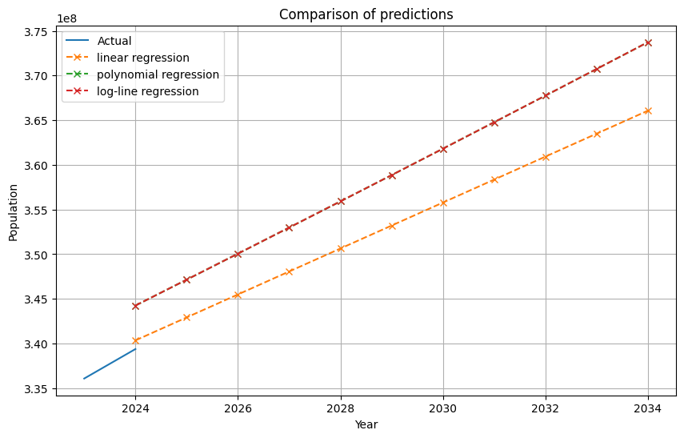

```python
plt.figure(figsize=(10,6))
plt.plot(actual_total["year"][actual_total["year"] >= 2023], actual_total["population"][actual_total["year"] >= 2023], label="Actual", linestyle='solid')
plt.plot(pred_lin["year"], pred_lin["predicted_population"], label="linear regression", linestyle='--', marker='x')
plt.plot(pred_pol["year"], pred_pol["predicted_population"], label="polynomial regression", linestyle='--', marker='x')
plt.plot(pred_log["year"], pred_log["predicted_population"], label="log-line regression", linestyle='--', marker='x')
plt.title("Comparison of predictions")
plt.xlabel("Year")
plt.ylabel("Population")
plt.grid(True)
plt.legend()
plt.show()
```

The impact of this project extends beyond simple population prediction—it highlights how data-driven modeling can guide important social and economic decisions. Accurate population forecasts can support policymakers in allocating resources for infrastructure, healthcare, and education, but they also raise ethical concerns about how predictive data might be misused to justify unequal funding or planning priorities. Through this project, I learned how different regression techniques affect model accuracy and how preprocessing decisions, such as pruning early data, can significantly improve performance. Experimenting with linear, polynomial, and log-linear models showed that selecting the right model for the data’s shape is critical for realistic predictions. Overall, this project deepened my understanding of how thoughtful data preparation and model choice can create powerful tools with real-world implications, both beneficial and cautionary.

## Sources:

https://www.geeksforgeeks.org/machine-learning/types-of-regression-techniques/